# Phase Transitions - Soft Matter Lecture 21 documentation

[figure not shown]

This page was generated from notebooks/L4/2_Phase_Transitions.ipynb.

# Phase Transitions

The importance of looking at phase transitions resides in the multicomponent nature of soft matter and its interaction energy scales.

## Liquid-Liquid Unmixing

Consider two liquids consisting of molecules A and B, which we will bring together and mix. The mixing should happen at constant volume and temperature. We can therefore use the Helmholtz free energy as the quantity that is minimized.

First we calculate the mixing entropy $S_{\rm mix}$ from

$\begin{equation} S=-k_{\rm B}\sum_{i}p_{i}\ln(p_{i}) \end{equation}$

which results in

$\begin{equation} S_{\rm mix}=-k_{\rm B}(\phi_{\rm A}\ln(\phi_{\rm A})+\phi_{\rm B}\ln(\phi_{\rm B})). \end{equation}$

In addition to the mixing entropy, we have to calculate the change of the internal energy as well. This internal energy consists of an energy term that comprises the interaction of two molecules of the same type A ($\epsilon_{\rm AA}$), one of two molecules of the same type B ($\epsilon_{\rm BB}$), and one between the molecules A and B ($\epsilon_{\rm AB}$). If we assume that each site in the liquid has a number of neighbors, then the interaction energy of this site is

$\begin{equation} z\phi_{\rm A}\epsilon_{\rm AA}. \end{equation}$

A fraction of $\phi_{\rm A}$ sites is occupied with molecules A and, thus, the interaction energy reads

$\begin{equation} \frac{z}{2}\phi_{\rm A}^2\epsilon_{\rm AA}. \end{equation}$

Similarly, expressions for the interaction of B molecules and the interaction of A with B can be obtained. To calculate the change in internal energy when mixing the two species, we still have to subtract the internal energy of the two separated components, $z\phi_{\rm A}\epsilon_{\rm AA}/2$ and $z\phi_{\rm B}\epsilon_{\rm BB}/2$, such that we obtain

$\begin{equation} U_{\rm mix}=\frac{z}{2}\left [(\phi_{\rm A}^2-\phi_{\rm A})\epsilon_{\rm AA}+(\phi_{\rm B}^2-\phi_{\rm B})\epsilon_{\rm BB}+2\phi_{\rm A}\phi_{\rm B}\epsilon_{\rm AB}\right]. \end{equation}$

Using this expression as well as the assumption $\phi_{\rm A}+\phi_{\rm B}=1$ (incompressibility of the mixture) we can define an interaction parameter

$\begin{equation} \chi=\frac{z}{2k_{\rm B}T}(2\epsilon_{\rm AB}-\epsilon_{\rm AA}-\epsilon_{\rm BB}) \end{equation}$

such that

$\begin{equation} \frac{U_{\rm mix}}{k_{\rm B}T}=\chi\phi_{\rm A}\phi_{\rm B} \end{equation}$

by utilizing, for example, $(\phi_{\rm A}^2-\phi_{\rm A})\epsilon_{\rm AA}=\phi_{\rm A}(\phi_{\rm A}-1)\epsilon_{\rm AA}=-\phi_{\rm A}\phi_{\rm B}\epsilon_{\rm AA}$.

This finally yields the free energy of mixing

$\begin{equation} \frac{F_{\rm mix}}{k_{\rm B}T}=\phi_{\rm A}\ln(\phi_{\rm A})+\phi_{\rm B}\ln(\phi_{\rm B})+\chi\phi_{\rm A}\phi_{\rm B}. \end{equation}$

We can now plot this free energy of mixing as a function of the volume fraction of component A.

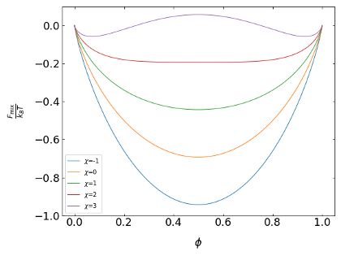

*Free energy of mixing as a function of the composition of the binary liquid mixture for different interaction parameters.*

The free energy function has a minimum at a composition of $\phi=0.5$ for all $\chi$ smaller than 2. In this region of interaction parameters, the two liquids are always miscible at any composition. For $\chi$ larger than two, the free energy function reveals two minima, i.e., there are two compositions under which the mixture is stable (one rich in phase B and one right in A). The location of these two minima defines what is called the **binodal** or **coexistence curve**, which separates the unstable from the stable region in a phase diagram (Figure 4). As the interaction parameter is proportional to $1/T$, these stable compositions are a function of the temperature.

To understand the stability of a mixture, let us shorten the notation first. In all of the following considerations, we will denote $\phi=\phi_{\rm A}.$ We will start with two mixtures we have prepared, which have a composition $\phi_1$ and $\phi_2$. If we take a volume $V_1$ of the first mixture and a volume $V_2$ of the second one and combine them to a volume $V_0$, then the two mixtures form again a new composition with

$\begin{equation} \phi_{0}V_{0}=\phi_{1}V_{1}+\phi_{2}V_{2}. \end{equation}$

We can divide by $V_0$ and introduce two new volume fractions $\alpha_1$, $\alpha_2$ to yield

$\begin{equation} \phi_{0}=\frac{V_{1}}{V_{0}}\phi_{1}+\frac{V_{2}}{V_{0}}\phi_{1}=\alpha_{1}\phi_{1}+\alpha_{2}\phi_{2}. \end{equation}$

The total free energy of the system of the two separated mixtures at these volume fractions can then be written as

$\begin{equation} F_{\rm sep}=\alpha_{1}F_{\rm mix}(\phi_{1})+\alpha_{2}F_{\rm mix}(\phi_{2}). \end{equation}$

[figure not shown]

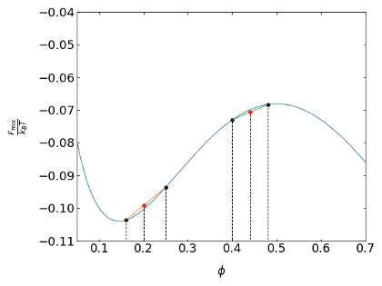

Apparently the above analysis has done nothing else than measuring the sign of the curvature of the free energy curve. We can summarize the conditions as

$\begin{eqnarray} \frac{\mathrm d^2F_{\rm mix}}{\mathrm d\phi^2}&>&0\ldots {\rm stable}\\ \frac{\mathrm d^2F_{\rm mix}}{\mathrm d\phi^2}&<&0\ldots {\rm unstable}\\ \frac{\mathrm d^2F_{\rm mix}}{\mathrm d\phi^2}&=&0\ldots {\rm spinodal\, line}\\ \frac{\mathrm d^3F_{\rm mix}}{\mathrm d\phi^3}&=&0\ldots {\rm critical\, point} \end{eqnarray}$

The spinodal line therefore separates the metastable from the unstable region. It corresponds to the deflection points of the free energy curve. The critical point, beyond which no phase separation can be achieved at any concentration $\phi$ is defined by setting the third derivative to zero.

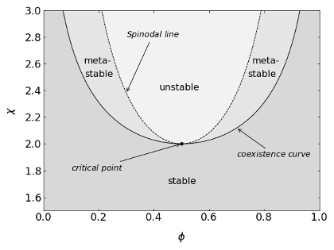

*Phase diagram of an ideal mixture. The interaction parameter is plotted as a function of the composition. The individual regions as defined by the above equation are indicated.*

## Kinetics of Liquid–Liquid unmixing

If two liquids are brought together at a composition that is either unstable or metastable, they will phase separate. The kinetics of this phase separation can proceed in different ways.

1. **Spinodal Decomposition** – In this case, thermal fluctuations will amplify density fluctuations. The material will diffuse “uphill” to the regions of higher concentration to yield phase separation. The boundaries of the two phases are blurred in this case. Spinodal decomposition is the process of phase separation in the unstable region.
2. **Nucleation** – In the case of nucleation, a thermal fluctuation will create a nucleus of a critical size, which further grows in time. The nucleus has a sharp boundary with the other phase. Nucleation is the process of phase separation in the metastable region.

We will treat both kinetic regimes separately.

### Spinodal decomposition

Based on Fick’s law, we know that the diffusion currents occur in the direction against a composition gradient, i.e., $J=-D∇\phi$. The result of that diffusion process is an equal composition in the whole sample. For phase separation to happen, material needs to flow from regions of low concentration to regions of higher concentration so in the direction of the composition gradient. Material transport is therefore not balancing composition gradients. In the section about the chemical potential, we learned that in an open system the chemical potential of all species is balanced. The chemical potential is given by

$\begin{equation} \mu=\frac{\mathrm dF}{\mathrm d\phi}|_{V,T}. \end{equation}$

If now the second derivative of the free energy with respect toϕis positive, the regions with largerϕhave larger free energy. Thus regions of lower concentration are favored by the free energy and the diffusion happens to be downhill as given also by Ficks law. If the second derivate of the free energy is, however, negative, then fluctuations in the composition will lower the free energy and thus, the fluctuations will grow in strength. The fluctuations with different length scales will, however, not grow at the same rate. The spectrum of growth rates can be described by a phenomenological theory known as the Cahn–Hilliard equation, which is applied in many fields. To arrive at that equation, we need to describe the free energy in terms of composition gradients

$\begin{equation} F=A\int \left [f_{0}(\phi)+\kappa \left( \frac{\mathrm d\phi}{\mathrm dx}\right)^2\right]\mathrm dx. \end{equation}$

Here, $f_0$ is the free energy density, $A$ an area and $x$ a linear coordinate. Actually, there is a more intuitive Ansatz by defining the free energy density as

$\begin{equation} f_{0}=\frac{a}{2}\phi^{2}+\frac{b}{4}\phi^4 \end{equation}$

This free energy density is able to resemble the free energy curve. To balance the chemical potentials we need to modify Ficks laws

$\begin{eqnarray} J &=& -D\frac{\mathrm d\phi}{\mathrm dx}\\ \frac{\mathrm d\phi}{\mathrm dt} &=& -\frac{\mathrm dJ}{\mathrm dx}\\ \frac{\partial\phi}{\partial x} &=& D\frac{\partial^{2}\phi}{\partial x^2} \end{eqnarray}$

to an appropriate new law

$\begin{equation} J=-M \frac{\mathrm d\mu}{\mathrm dx}. \end{equation}$

where $\mu=\mu_{\rm A}-\mu_{\rm B}$ is the difference between the chemical potential of $A$ and $B$. This is apparently a linear approximation. According to the definition of the chemical potential, we obtain

$\begin{equation} \mu=\frac{\mathrm d}{\mathrm d\phi}\left [f_{0}(\phi)+\kappa \left( \frac{\mathrm d\phi}{\mathrm dx}\right)^2\right] \end{equation}$

from which follows

$\begin{equation} \mu=\frac{df_{0}}{\mathrm d\phi}+2\kappa\frac{\mathrm d^2\phi}{\mathrm dx^2}. \end{equation}$

Inserting this into our modified Ficks low yields

$\begin{equation} J=-M f_{0}^{''}\frac{\mathrm d\phi}{\mathrm dx}+2M\kappa \frac{\mathrm d\phi^{3}}{\mathrm dx^3} \end{equation}$

with $f_0^″=(d^2 f_0)/(dϕ^2)$. Finally, inserting the above equation into the continuity equation yields

$\begin{equation} \frac{\partial \phi}{\partial t}=M f_{0}^{''}\frac{\partial ^2\phi}{\partial x^2}-2M\kappa \frac{\partial^4 \phi}{\partial x^4}. \end{equation}$

This is the **Cahn–Hilliard** equation, which extends the diffusion equation for interacting species. The term in front of the second derivative yields an effective diffusion coefficient, i.e., $D_{\rm eff}=M f_{0}^{''}$. While the coefficient $M$ (the Onsager coefficient) is always positive, the second derivative of the free energy density $f_0$ can be positive or negative. Inside the spinodal line, for example, the curvature of the free energy is negative. Following that, the effective diffusion coefficient is negative which allows for our uphill diffusion. The Cahn–Hilliard equation can be solved by a Fourier decomposition which yields

$\begin{equation} \phi(x,t)=\phi_{0}+A\cos(qx)\exp\left [ -D_{\rm eff} q^{2}\left (1+\frac{2\kappa q^{2}}{f_{0}^{''}}\right ) t\right ]. \end{equation}$

Here $q$ is a wavenumber defining the wavelength of the fluctuations. The exponent can be abbreviated by

$\begin{equation} R(q)= -D_{\rm eff} q^{2}\left (1+\frac{2\kappa q^{2}}{f_{0}^{''}}\right ) \end{equation}$

which is nothing else as an inverse time, or a rate coefficient. It provides the relaxation rate for a specific wavenumber. This rate coefficient is positive up to a certain wavenumber $q_0$. All fluctuations with wavelength larger than $λ_0=2π/q_0$ are amplified in time. The fastest-growing fluctuation is obtained at $q_{\rm max}$. This wavenumber sets the length scale of the structures, which typically appear during the spinodal decomposition.

### Nucleation

Nucleation is the phenomenon of spontaneously generating a phase-separated volume by thermal fluctuations. By doing that, we create an interface between the two phases, which costs energy. We, therefore, have a first simple look at the interfacial energy.

### Interfacial Tension

If we have a system of two components A and B and those components do not mix but form an interface, then due to the fact that both sorts of molecules repel each other, we have to spend energy to bring them together. The work done to create add an interfacial area is

$\begin{equation} W=F \Delta x=\gamma L \Delta x, \end{equation}$

where $γ$ denotes the interfacial energy. If work is done, this would require an energy exchange with a reservoir to keep the temperature constant. That, however, also means that the interfacial energy is a free energy per unit area rather than internal energy. Interfacial energies may contain entropic contributions. In the case of a sharp interface, we can use the interaction parameter $χ$ and the molecular volume $v$ to show

$\begin{equation} \gamma=\frac{1}{2v^{2/3}}(2\epsilon_{\rm AB}-\epsilon_{\rm AA}-\epsilon_{\rm BB})=\frac{\chi k_{\rm B}T}{zv^{2/3}}. \end{equation}$

### Nucleation

If we have a liquid mixture now at a certain composition, which is in the metastable region, i.e., $(∂^2 F)/(∂ϕ^2 )>0$, all of the density fluctuations in our system are damped and the spinodal decomposition can not happen. Therefore, the system has to phase separate by nucleation, i.e., that spontaneously a droplet of a certain sizeris formed and grows further. As we need energy to create the interface but also gain free energy by forming a volume phase, we need to have a look at the total free energy change, when the droplet is formed.

- the volume part is delivering a free energy gain per volume of $ΔF_v<0$, which has to be multiplied with the volume of the droplet.
- the creation of an interface requires interfacial energy $γ$, which is always positive and has to be multiplied with the droplet surface area.

Thus, the total free energy change reads

$\begin{equation} \Delta F(r)=\frac{4}{3}\pi r^3\Delta F_{v}+4\pi r^2 \gamma. \end{equation}$

Note that the first term is negative as $ΔF_v$ is negative. A typical free energy change with the particle size is shown in the figure below. It has maximum at the position $r^*$,which creates a nucleation barrier $ΔG^*$. Droplets which are spontaneously formed at $r<r^*$ can decrease their free energy by dissolving.

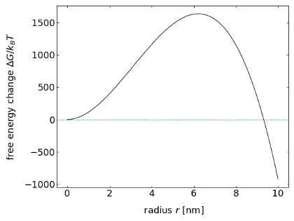

## Solid–Liquid Phase Transitions

When a liquid is cooled down and reaches the (freezing) melting temperature, the liquid may enter the solid phase. Directly at the melting temperature, the free energy of the solid and the liquid are the same (also the chemical potentials). When forming a crystal, the system needs to spend energy on creating the interface between liquid and solid, which requires a surface free energy to come from somewhere. The transition from the liquid to the solid, however, is not freeing any energy. As a result, the liquid cannot freeze directly at the freezing temperature. To freeze the liquid, undercooling is required. An undercooling by a temperature $ΔT$ would create a free energy difference $ΔG$ between liquid and solid.

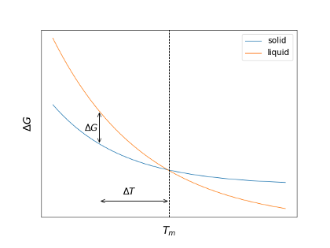

*Free energy of solid and liquid phase of a material as a function of temperature*

### Kinetics of liquid–solid phase transition

To start the phase transition from a liquid to a solid in the undercooled liquid, a nucleus of a certain size has to appear from thermal fluctuations. This goes along the lines we discussed for the liquid-liquid phase transitions. To create a nucleus of a radiusrwe need a free energy change

$\begin{equation} \Delta G= \frac{4}{3}\pi r^3\Delta G_b+4\pi r^2\gamma_{sl}, \end{equation}$

where $ΔG_b$ is the free energy change per unit volume, when creating the volume phase of the solid material.$γ_{sl}$ denotes the interfacial free energy for the solid/liquid contact. We also know that at a first-order phase transition all energy inserted into the system (the latent heat $ΔH_m$ at the melting temperature $T_m$) is going into a change in the entropy of the system, i.e.,

$\begin{equation} \Delta S_{m}=\left (\frac{\partial G_{s}}{\partial T}\right )_{p}-\left (\frac{\partial G_{l}}{\partial T}\right )_{p}=\frac{\Delta H_{m}}{T_{m}}. \end{equation}$

We can, therefore, extrapolate the free energy change at the undercooled temperature by

$\begin{equation} \Delta G_{b}=-\frac{\Delta H_{m}}{T_{m}}\Delta T \end{equation}$

which yields

$\begin{equation} \Delta G= -\frac{4}{3}\pi r^3\frac{\Delta H_{m}}{T_{m}}\Delta T +4\pi r^2\gamma_{sl}. \end{equation}$

According to our nucleation theory, this yields a critical radius of the nucleus of

$\begin{equation} r^{*}=\frac{2\gamma_{sl}T_{m}}{\Delta H_{m}\Delta T}. \end{equation}$

A nucleus of size $r<r^*$ would thus have the tendency to dissolve again, while a nucleus of size $r>r^*$ is ready to grow continuously. The critical radius of the nucleus is corresponding to a free energy barrier

$\begin{equation} \Delta G^{*}=\frac{16\pi}{3}\gamma_{sl}^3\left (\frac{T_{m}}{\Delta H_{m}}\right )^2\frac{1}{\Delta T^2}. \end{equation}$

The probability of critical nucleus formation can thus be determined from the Boltzmann factor

$\begin{equation} e^{\frac{\Delta G^{*}}{k_{\rm B}T}} \end{equation}$

which is a very strong function of temperature. Inserting typical values, e.g., for water/ice we find the following free energies as a function of the nucleus radius ($\Delta T= 10\, {\rm K}$).

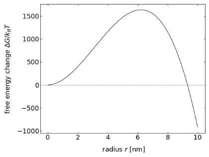

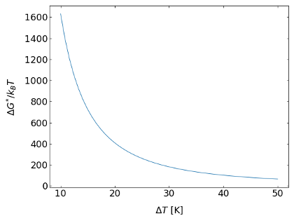

According to that, homogeneous nucleation, i.e., the freezing of a liquid is very unlikely and actually does not happen. More likely are heterogeneous nucleation events, which occur at the boundaries of the container or at impurities. Heterogeneous nucleation To study the process of heterogeneous nucleation we have a look at a container wall, which acts as a nucleation catalyst. At this container wall, a solid droplet in form of a spherical cap exists.

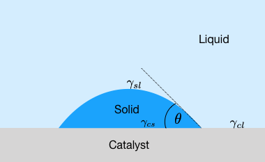

The solid material shall have a contact angle of $θ$ with the catalyst surface. In this case, the contact angle obeys Youngs law $γ_sl\cos(θ)=γ_{cl}-γ_{cs}$. Further, for the calculation of the volume and interfacial contributions, we need the volume and the surfaces of the spherical cap as well as the surface at the catalyst interface, which all together read

$\begin{eqnarray} V&=& \frac{1}{3}\pi r^3 (1-\cos(\theta))^2(2+\cos(\theta))\\ S_{sl}&=&2\pi r^2 (1-\cos(\theta))\\ S_{cs}&=&\pi r^2\sin^2(\theta) \end{eqnarray}$

Following the earlier arguments, we can write down the free energy change upon nucleation of a spherical cap of a radiusrat the catalyst surface as

$\begin{eqnarray} \Delta G(r)&=& \frac{1}{3}\pi r^3 (1-\cos(\theta))^2(2+\cos(\theta))\\ &&+ \gamma_{sl}2\pi r^2 (1-\cos(\theta))\\ &&+ \gamma_{cs}\pi r^2 \sin^2(\theta)\\ &&-\gamma_{cl}\pi r^2 \sin^2(\theta)\\ \end{eqnarray}$

With the help of Youngs equation, we can simplify this to

$\begin{equation} \Delta G^{*}=\frac{16\pi}{3}\gamma_{sl}^3\left (\frac{T_{m}}{\Delta H_{m}}\right)^2 \frac{1}{\Delta T^2}\left ( \frac{(1-\cos(\theta))^2(2+\cos(\theta))}{4}\right ). \end{equation}$

The latter fraction is actually only an additional geometrical factor that depends only on $θ$,while all factors before just resemble the homogeneous nucleation result. The graph below displays this geometrical factor $f(θ)$ as a function of the contact angle $θ$ and indicates that the creation of a nucleus with a certain contact angle at a solid wall considerably lowers the nucleation barrier. The nucleation barrier can thus be easily as low as thermal energy as shown in the graph below for the water/ice system. The nucleus size in that model stays the same, while a contact angle of about 14° yields a nucleation barrier of $1\, k_{\rm B}T$.

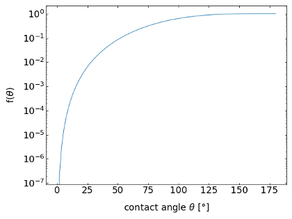

*Geometry factor for the heterogeneous nucleation of a droplet with a contact angle at a catalyst wall*

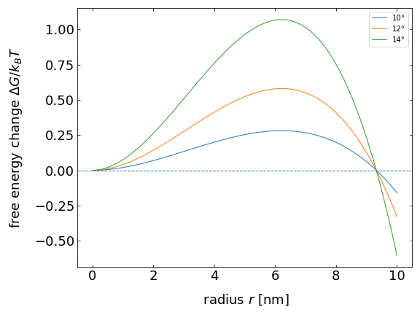

*Nucleation barrier as a function of nucleus radius for heterogeneous nucleation at a wall. The curves display the results for the water/ice interface.*